# Milestone Report

Alexander Klonov

22 11 2020

## Milestone report

### Goal

The goal of this project is just to display that I’ve gotten used to working with the data and that I am on track to create1 prediction algorithm.

### Motivation

The motivation for this project is to:

- Demonstrate that I’ve downloaded the data and have successfully loaded it in.
- Create a basic report of summary statistics about the data sets.
- Report any interesting findings that I amassed so far.
- Get feedback on plans for creating a prediction algorithm and Shiny app.

### Downloading files

Link to all archives is here. Data consists of sentences from three different sources such as news, twitter and blogs. There were several languages, but I decided to stick with English language.

### Basic summary

Lines and words count in each file:

- Blogs

```
## [1] 899288
```

```
## [1] 37132075
```

- News

```
## [1] 77259
```

```
## [1] 2622252
```

- Twitter

```
## [1] 2360148
```

```
## [1] 29581900
```

### How data looks like

All data looks like this:

```
## [1] "How are you? Btw thanks for the RT. You gonna be in DC anytime soon? Love to see you. Been way, way too long."
## [2] "When you meet someone special... you'll know. Your heart will beat more rapidly and you'll smile for no reason."
## [3] "they've decided its more fun if I don't."
## [4] "So Tired D; Played Lazer Tag & Ran A LOT D; Ughh Going To Sleep Like In 5 Minutes ;)"
## [5] "Words from a complete stranger! Made my birthday even better :)"
## [6] "First Cubs game ever! Wrigley field is gorgeous. This is perfect. Go Cubs Go!"
```

## Explanatory analyses

Setting seed for reproducible research.

```r
set.seed(3999)
```

Since datasets are too big, it’s wise to split them into samples.

Using *NGramTokenizer* we can split our data into tokens we can use in prediction model

```
##          Var1 Freq
## 58147  of the  803
## 41504  in the  762
## 88125  to the  356
## 31127 for the  287
## 59169  on the  286
## 7007  and the  267
```

How let’s make some visualizations

WordCloud can show most popular words in our combines sample

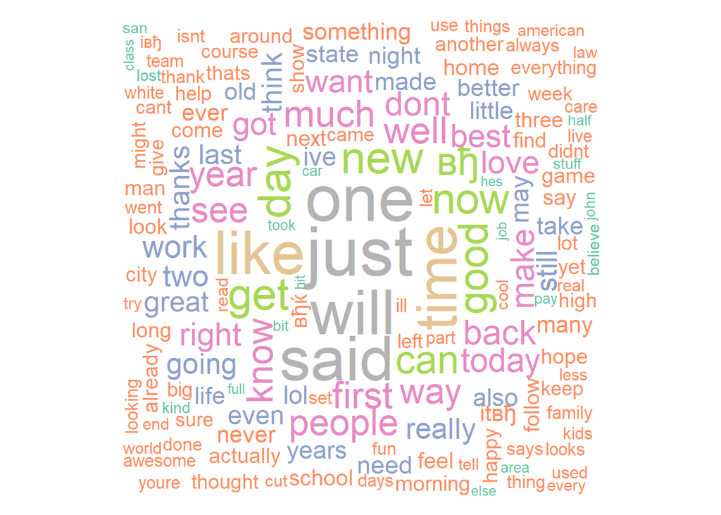

And some barplots for 2 and 3 words combinations

#### Bigrams

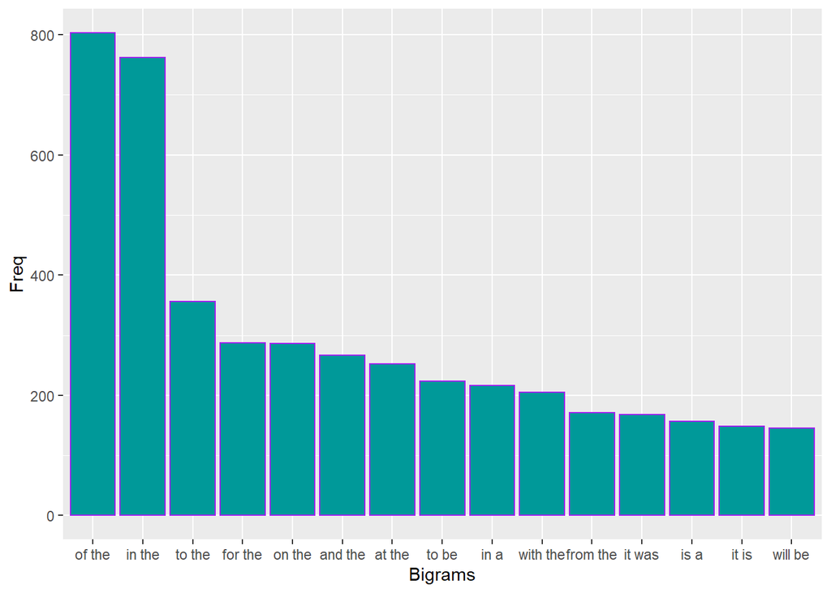

#### Trigrams

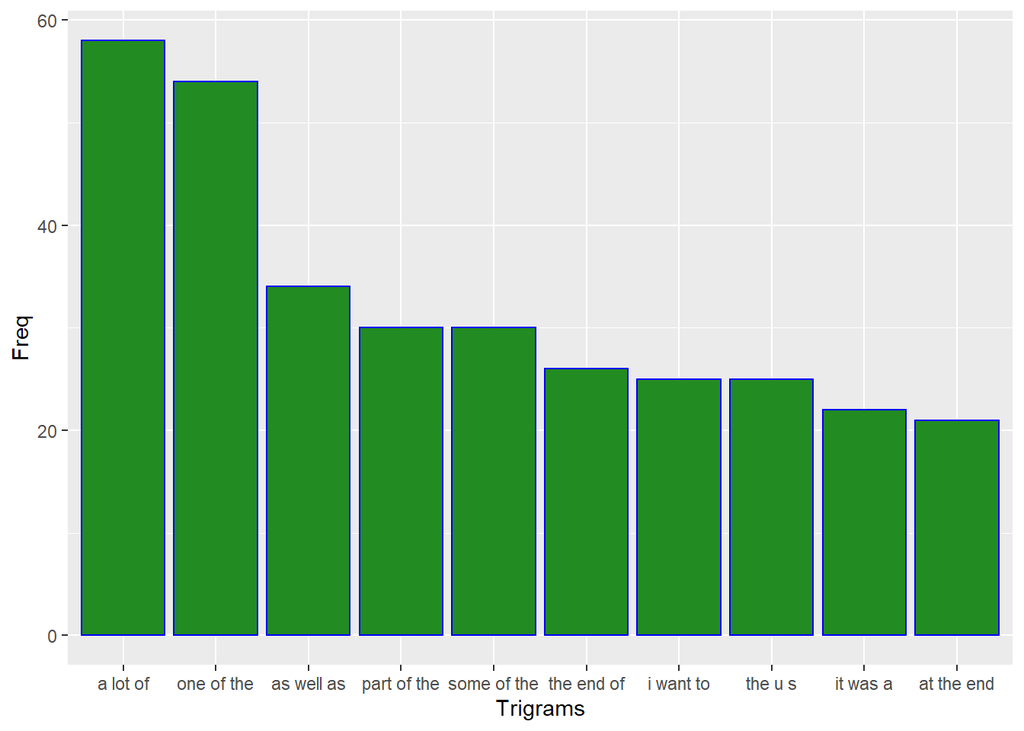

### Conclusion

So far, I’ve downloaded data, splitted it into words and grams. These objects can be used to make prediction models.